# Gain Mismatch systematics

```python
import healpy as hp
import pylab as pl
```

## Goal of these studies

We study the systematics effects induced by gain mismatches for Litebird scanning strategy and a fake focal plane with just 2 detector pairs (to save computation time and memory at NERSC).

We inject **gain drifts** only in one of the two detectors as random Gaussian fluctations around 0 and with a 5% width during **1 precession period**. We then apply the gain estimates (and correct for it the TODs) by regressing the signal from each detector with a template, *dipole*.

We correct for the noise bias as described [here](https://en.wikipedia.org/wiki/Errors-in-variables_models) . According to the above entry the biased coefficient $\hat{g}$ is related to the true one $g$ by:

$ \hat{g} = g \frac{1}{1+ \sigma_{uncorr} ^2/\sigma_{corr}^2 }$

where $g$ is the slope parameter obtained by regressing of TOD of detector $i$, $d_{t,i}$ and the signal only template $s_t$, $\sigma_{uncorr}$ is the variance of uncorrelated component, defined as $\sigma^2_{uncorr}= Var(d_t -s_t)/2$, and $\sigma_{corr}$, is the variance of correlated component $\sigma^2_{corr}= Var(d_t) -\sigma^2_{uncorr} $

The whole systematics pipeline is within the TOAST framework.

## Simulation Settings

- simulate 1 yr of observations with LB scanning strategy parameters, $\alpha=45$, $\beta =50$, $spinrate=0.1 rpm $, $precperiod=96.5 min$
- Focal plane encodes 4 detectors (two det. pairs) at 140 GHz , FWHM= 25 arcmin, NET= 38.6 $\mu K \sqrt{s}$, sample rate= 40 Hz
- not spinning HWP /!\
- $f_{knee}$ is allowed to range 0,20, 50 mHz
- Input signal : CMB T only map + Dipole + Noise
- Output maps : destriped with MADAM (baseline=1min, noisefilter=Off)

Let's have a look of the hitmaps..

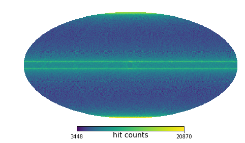

```python
hits= hp.read_map(field=0 , filename='/Users/peppe/work/satellite_sims/madam_hmap.fits',verbose =False)
lmax=3*hp.get_nside(hits)
l=pl.arange(2, lmax+1)
bl=hp.gauss_beam(lmax=lmax, fwhm=pl.deg2rad(10/60))[2:]
hp.mollview(hits, unit='hit counts', title=' ', sub=111, norm='log' )
cmbmaps=hp.read_map(field=range(3), filename='/Users/peppe/work/satellite_sims/sigonly/CMB_TQU_256_r0_1deg.fits',nest=True,verbose =False)

inputclfile ='/Users/peppe/work/satellite_sims/sigonly/inputcl.fits'
try :
    cl = hp.read_cl(filename=inputclfile)
except IOError:
    cl=hp.anafast(cmbmaps, lmax=lmax)
    hp.write_cl(cl=cl, filename='inputclfile' )
```

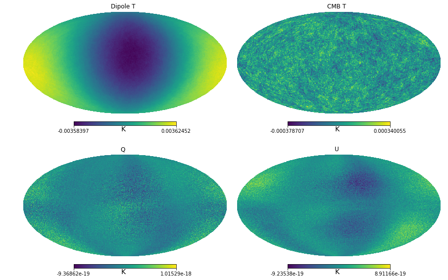

```python
dipolemap= hp.read_map(field=range(3) ,
                       filename='/Users/peppe/work/satellite_sims/sigonly/dipole/madam_map.fits',
                       verbose=False)

sigonlymap = hp.read_map(field=range(3) ,
                       filename='/Users/peppe/work/satellite_sims/sigonly/dipole_CMB_T/madam_map_003.fits',
                       verbose=False)
fig=pl.figure(figsize=(12,8))
hp.mollview(sigonlymap [0], unit='K ', title='Dipole T  ', sub=221 , fig=fig )
cmbT =sigonlymap [0] - dipolemap[0]
hp.mollview(cmbT , unit='K ', title='CMB T  ', sub=222 , fig=fig )
hp.mollview(sigonlymap [1], unit='K ', title='Q  ', sub=223 , fig=fig )
hp.mollview(sigonlymap [2], unit='K ', title='U  ', sub=224 , fig=fig )
```

Temperature map encodes = Dipole + CMB T. Polariz. maps are essentially null

### we now inject gain drifts to signal only observations

We look at **residual** maps, i.e.  
$ \Delta m = m_{out} - m_{in} $

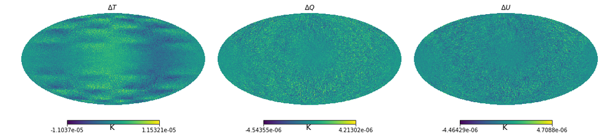

```python
driftmap= hp.read_map(field=range(3) ,
                       filename='/Users/peppe/work/satellite_sims/sigonly/uncorr/madam_map.fits',
                       verbose=False)
fig=pl.figure(figsize=(15,8))
hp.mollview(driftmap [0]- sigonlymap[0] , unit='K ', title=r'$\Delta T$  ', sub=131 , fig=fig )
hp.mollview(driftmap [1], unit='K ', title=r'$\Delta Q$', sub=132 , fig=fig )
hp.mollview(driftmap [2], unit='K ', title=r'$\Delta U$', sub=133 , fig=fig )
cldrifts=hp.anafast(driftmap-sigonlymap, lmax=lmax)
```

We get non null signal to Q, and U maps, that's the expected T-> P leakage from gain drifts.

We thus estimate the gains and apply the correction at the TOD level, as depicted above

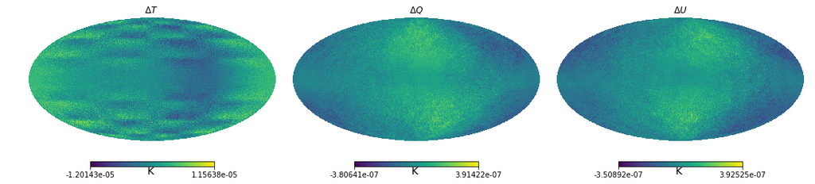

```python
driftcorrmap= hp.read_map(field=range(3) ,
                       filename='/Users/peppe/work/satellite_sims/sigonly/corr/madam_map.fits',
                       verbose=False)
fig=pl.figure(figsize=(15,8))
hp.mollview(driftcorrmap [0]- sigonlymap[0] , unit='K ', title=r'$\Delta T$  ', sub=131 , fig=fig )
hp.mollview(driftcorrmap [1], unit='K ', title=r'$\Delta Q$', sub=132 , fig=fig )
hp.mollview(driftcorrmap [2], unit='K ', title=r'$\Delta U$', sub=133 , fig=fig )
cldriftcorr=hp.anafast(driftcorrmap-sigonlymap , lmax=lmax)
```

You may notice that residual Q and U maps are a factor ~10 times smaller than the ones w/o any gain correction (see above ).

We then compute full sky power spectra (with `anafast`) from the residual maps, $\Delta m$.

```
(767,)
```

```
(2.0, 600)
```

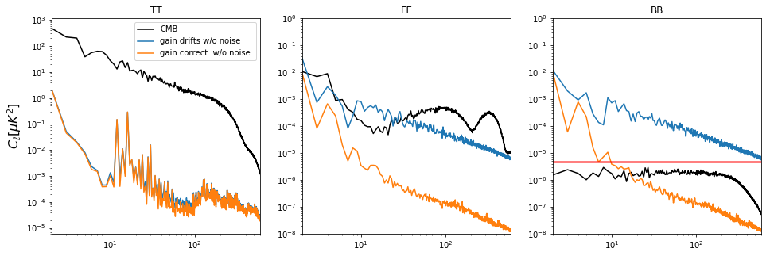

```python
print bl.shape
fig=pl.figure(figsize=(16, 5))
pl.subplot(131)
pl.title('TT')
pl.ylabel(r'$C_{\ell} [ \mu K^2 ]$', fontsize=16)
pl.loglog(l, cl[0][2:]/bl**2 *1e12,'k', label='CMB')
pl.loglog(l, cldrifts[0][2:]/bl**2 *1e12, label='gain drifts w/o noise ')
pl.loglog(l, cldriftcorr[0][2:]/bl**2 *1e12, label='gain correct. w/o noise ')
pl.legend(loc='upper right')
pl.xlim([0,600])

pl.subplot(132)
pl.title('EE')
pl.loglog(l,cl[1][2:]/bl**2  *1e12,'k')
pl.loglog(l, cldrifts[1][2:]/bl**2 *1e12)
pl.loglog(l, cldriftcorr[1][2:]/bl**2 *1e12)

pl.ylim([1e-8,1e0])
pl.xlim([0,600])
pl.subplot(133)
pl.title('BB')
pl.loglog(l, cl[2][2:] /bl**2 *1e12,'k')
pl.loglog(l, cldrifts[2][2:]/bl**2 *1e12)
pl.loglog(l, cldriftcorr[2][2:]/bl**2 *1e12)
pl.loglog(l, pl.ones_like(l)*4.87e-6,'r', alpha=.5, linewidth=3)
pl.ylim([1e-8,1e0])
pl.xlim([0,600])
```

Recall that no noise has been coadded to the TODs so far, so that the plots above represent the level of accuracy our estimator might achieve. As a reference, we include in BB plot the **solid red** line resembling the ultimate Litebird whitenoise level of $7.6 \mu $K arcmin, after FG subtraction.

**Pros:** By comparing the blue with the orange solid lines should highlights the effects of gain correction. As expected they are small for the temperature maps, but in terms of EE and BB power the correction is very effective: it may correct the T->P leakage as much as 3 orders of magnitude.

**Cons**: there is a lot of power at $\ell<10$ scales.

### Add white noise to the TODs

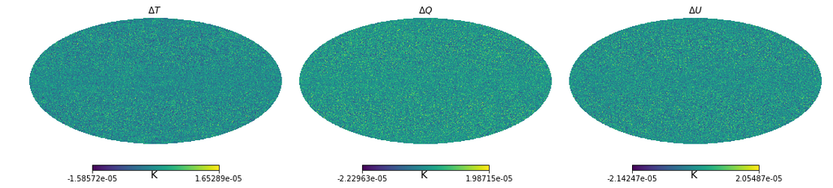

```python
nodriftmap= hp.read_map(field=range(3) ,
                           filename='/Users/peppe/work/satellite_sims/whitenoise/nodrifts/madam_map.fits',
                       verbose=False)
fig=pl.figure(figsize=(15,8))
hp.mollview(nodriftmap [0]- sigonlymap[0] , unit='K ', title=r'$\Delta T$  ', sub=131 , fig=fig )
hp.mollview(nodriftmap [1], unit='K ', title=r'$\Delta Q$', sub=132 , fig=fig )
hp.mollview(nodriftmap [2], unit='K ', title=r'$\Delta U$', sub=133 , fig=fig )
clnodrift=hp.anafast(nodriftmap -sigonlymap , lmax=lmax)
whitenoiselevelT= clnodrift [0][100:].mean() *1e12 *pl.ones_like(l)
whitenoiselevelP= clnodrift [1][100:].mean() *1e12 *pl.ones_like(l)
```

### Then inject gain drifts w/ noisy TODs (white noise only )

```python
driftuncmap= hp.read_map(field=range(3) ,
                           filename='/Users/peppe/work/satellite_sims/whitenoise/madam_map_001.fits',
                       verbose=False)

cluncd =hp.anafast(driftuncmap -sigonlymap , lmax=lmax)
driftcmap= hp.read_map(field=range(3) ,
                           filename='/Users/peppe/work/satellite_sims/whitenoise/madam_map.fits',
                       verbose=False)
clcd =hp.anafast(driftcmap -sigonlymap , lmax=lmax)
```

```
(2.0, 600)
```

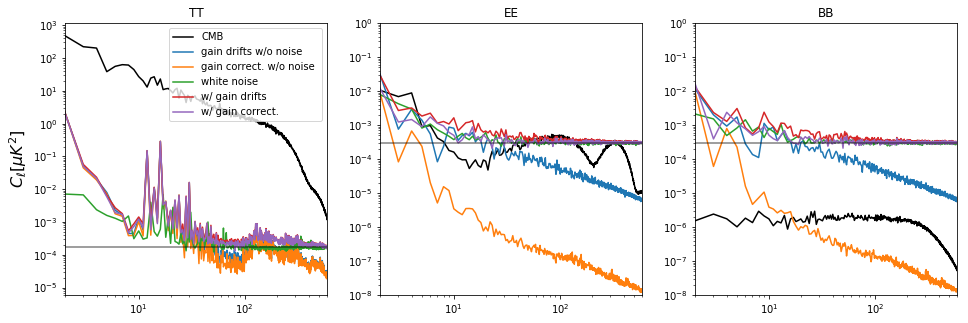

```python
fig=pl.figure(figsize=(16, 5))
pl.subplot(131)
pl.title('TT')
pl.ylabel(r'$C_{\ell} [ \mu K^2 ]$', fontsize=16)
pl.loglog(l, cl[0][2:]/bl**2 *1e12,'k', label='CMB')
pl.loglog(l, cldrifts[0][2:]/bl**2 *1e12, label='gain drifts w/o noise ')
pl.loglog(l, cldriftcorr[0][2:]/bl**2 *1e12, label='gain correct. w/o noise ')
pl.loglog(l, clnodrift [0][2:]/bl**2 *1e12, label='white noise ')
pl.loglog(l, cluncd [0][2:]/bl**2 *1e12, label='w/ gain drifts ')
pl.loglog(l, clcd [0][2:]/bl**2 *1e12, label='w/ gain correct. ')
pl.loglog(l, whitenoiselevelT, 'k', alpha=.5)

pl.legend(loc='upper right')
pl.xlim([0,600])

pl.subplot(132)
pl.title('EE')
pl.loglog(l,cl[1][2:]/bl**2  *1e12,'k')
pl.loglog(l, cldrifts[1][2:]/bl**2 *1e12)
pl.loglog(l, cldriftcorr[1][2:]/bl**2 *1e12)
pl.loglog(l, clnodrift [1][2:]/bl**2 *1e12)
pl.loglog(l, cluncd [1][2:]/bl**2 *1e12)
pl.loglog(l, clcd [1][2:]/bl**2 *1e12)
pl.loglog(l, whitenoiselevelP, 'k', alpha=.5)

pl.ylim([1e-8,1e0])
pl.xlim([0,600])
pl.subplot(133)
pl.title('BB')
pl.loglog(l, cl[2][2:] /bl**2 *1e12,'k')
pl.loglog(l, cldrifts[2][2:]/bl**2 *1e12)
pl.loglog(l, cldriftcorr[2][2:]/bl**2 *1e12)
pl.loglog(l, clnodrift [2][2:]/bl**2 *1e12)
pl.loglog(l, cluncd [2][2:]/bl**2 *1e12)
pl.loglog(l, clcd [2][2:]/bl**2 *1e12)
pl.loglog(l, whitenoiselevelP, 'k', alpha=.5)

pl.ylim([1e-8,1e0])
pl.xlim([0,600])
```

#### If there is noise in the data, the gain estimator can't go further beyond the noise level.

As a reference we plot the white noise threshold as a grey solid line. However, we wanna be sure that we actually reach the expected white noise level with our estimator. We therefore run $N_{MC} = 25$ simulations of the very same configuration by only changing the random seed for the noise realization.  
We estimate the mean and the std at each bin and B-modes spectra are shown below.

```
(2, 600)
```

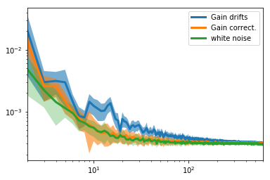

```python
wn= hp.read_cl('/Users/peppe/work/satellite_sims/whitenoise_only.fits')
unc= hp.read_cl('/Users/peppe/work/satellite_sims/whitenoise_drift_uncorr.fits')
cor= hp.read_cl('/Users/peppe/work/satellite_sims/whitenoise_drift_corr.fits')

pl.loglog(l, cor[0,2:]*1e12, linewidth=3, label='Gain drifts' )
pl.fill_between(l, (cor[0,2:] -cor[1,2:]) *1e12,(cor[0,2:] + cor[1,2:]) *1e12,
                   alpha=.6)
pl.loglog(l, unc[0,2:]*1e12, linewidth=3 , label='Gain correct.')
pl.fill_between(l, (unc[0,2:] -unc[1,2:]) *1e12,(unc[0,2:] + unc[1,2:]) *1e12,
                   alpha=.6)
pl.loglog(l, wn[0,2:]*1e12, linewidth=3 , label='white noise')
pl.fill_between(l, (wn[0,2:] -wn[1,2:]) *1e12,(wn[0,2:] + wn[1,2:]) *1e12,
                   alpha=.3)
pl.legend(loc='best')
#pl.ylim([1e-8,1e0])
pl.xlim([2,600])
```

We now complicate a bit more the noise model by adding the 1/f.

### 1/f noise TODs, fknee=50 mHz

```python
nodriftmap1= hp.read_map(field=range(3) ,
                        filename='/Users/peppe/work/satellite_sims/fknee_50mHz/nodrifts/madam_map.fits',
                       verbose=False)
clnodrift1=hp.anafast(nodriftmap1 -sigonlymap , lmax=lmax)
driftuncmap1= hp.read_map(field=range(3) ,
                           filename='/Users/peppe/work/satellite_sims/fknee_50mHz/madam_map_001.fits',
                       verbose=False)
cluncd1 =hp.anafast(driftuncmap1-sigonlymap , lmax=lmax)
driftcmap1= hp.read_map(field=range(3) ,
                           filename='/Users/peppe/work/satellite_sims/fknee_50mHz/madam_map.fits',
                       verbose=False)
clcd1 =hp.anafast(driftcmap1 -sigonlymap , lmax=lmax)
```

```
(2.0, 600)
```

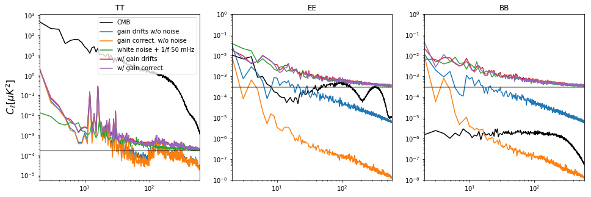

```python
fig=pl.figure(figsize=(16, 5))
pl.subplot(131)
pl.title('TT')
pl.ylabel(r'$C_{\ell} [ \mu K^2 ]$', fontsize=16)
pl.loglog(l, cl[0][2:]/bl**2 *1e12,'k', label='CMB')
pl.loglog(l, cldrifts[0][2:]/bl**2 *1e12, label='gain drifts w/o noise ')
pl.loglog(l, cldriftcorr[0][2:]/bl**2 *1e12, label='gain correct. w/o noise ')
pl.loglog(l, clnodrift1 [0][2:]/bl**2 *1e12, label='white noise + 1/f 50 mHz')
pl.loglog(l, cluncd1 [0][2:]/bl**2 *1e12, label='w/ gain drifts ')
pl.loglog(l, clcd1 [0][2:]/bl**2*1e12, label='w/ gain correct. ')
pl.loglog(l, whitenoiselevelT, 'k', alpha=.5)

pl.legend(loc='upper right')
pl.xlim([0,600])

pl.subplot(132)
pl.title('EE')
pl.loglog(l,cl[1][2:]/bl**2  *1e12,'k')
pl.loglog(l, cldrifts[1][2:]/bl**2 *1e12)
pl.loglog(l, cldriftcorr[1][2:]/bl**2 *1e12)
pl.loglog(l, clnodrift1 [1][2:]/bl**2 *1e12)
pl.loglog(l, cluncd1 [1][2:]/bl**2 *1e12)
pl.loglog(l, clcd1 [1][2:]/bl**2 *1e12)
pl.loglog(l, whitenoiselevelP, 'k', alpha=.5)

pl.ylim([1e-8,1e0])
pl.xlim([0,600])
pl.subplot(133)
pl.title('BB')
pl.loglog(l, cl[2][2:] /bl**2 *1e12,'k')
pl.loglog(l, cldrifts[2][2:]/bl**2 *1e12)
pl.loglog(l, cldriftcorr[2][2:]/bl**2 *1e12)
pl.loglog(l, clnodrift1 [2][2:]/bl**2 *1e12)
pl.loglog(l, cluncd1 [2][2:]/bl**2 *1e12)
pl.loglog(l, clcd1 [2][2:]/bl**2 *1e12)
pl.loglog(l, whitenoiselevelP, 'k', alpha=.5)

pl.ylim([1e-8,1e0])
pl.xlim([0,600])
```

### The case w/ a smaller fknee, 20 mHz

```python
nodriftmap2= hp.read_map(field=range(3) ,
                        filename='/Users/peppe/work/satellite_sims/fknee_20mHz/nodrifts/madam_map.fits',
                       verbose=False)
clnodrift2=hp.anafast(nodriftmap2 -sigonlymap , lmax=lmax)
driftuncmap2= hp.read_map(field=range(3) ,
                           filename='/Users/peppe/work/satellite_sims/fknee_20mHz/madam_map_001.fits',
                       verbose=False)
cluncd2 =hp.anafast(driftuncmap2-sigonlymap , lmax=lmax)

driftcmap2= hp.read_map(field=range(3) ,
                           filename='/Users/peppe/work/satellite_sims/fknee_20mHz/madam_map.fits',
                       verbose=False)
clcd2 =hp.anafast(driftcmap2 -sigonlymap , lmax=lmax)
```

```
(2.0, 600)
```

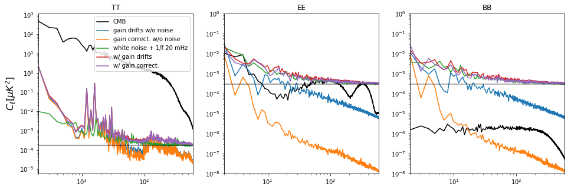

```python
fig=pl.figure(figsize=(16, 5))
pl.subplot(131)
pl.title('TT')
pl.ylabel(r'$C_{\ell} [ \mu K^2 ]$', fontsize=16)
pl.loglog(l, cl[0][2:]/bl**2 *1e12,'k', label='CMB')
pl.loglog(l, cldrifts[0][2:]/bl**2 *1e12, label='gain drifts w/o noise ')
pl.loglog(l, cldriftcorr[0][2:]/bl**2 *1e12, label='gain correct. w/o noise ')
pl.loglog(l, clnodrift2 [0][2:]/bl**2 *1e12, label='white noise + 1/f 20 mHz')
pl.loglog(l, cluncd2 [0][2:]/bl**2 *1e12, label='w/ gain drifts ')
pl.loglog(l, clcd2 [0][2:]/bl**2*1e12, label='w/ gain correct.')
pl.loglog(l, whitenoiselevelT, 'k', alpha=.5)

pl.legend(loc='upper right')
pl.xlim([0,600])

pl.subplot(132)
pl.title('EE')
pl.loglog(l,cl[1][2:]/bl**2  *1e12,'k')
pl.loglog(l, cldrifts[1][2:]/bl**2 *1e12)
pl.loglog(l, cldriftcorr[1][2:]/bl**2 *1e12)
pl.loglog(l, clnodrift2 [1][2:]/bl**2 *1e12)
pl.loglog(l, cluncd2 [1][2:]/bl**2 *1e12)
pl.loglog(l, clcd2 [1][2:]/bl**2 *1e12 )
pl.loglog(l, whitenoiselevelP, 'k', alpha=.5)

pl.ylim([1e-8,1e0])
pl.xlim([0,600])
pl.subplot(133)
pl.title('BB')
pl.loglog(l, cl[2][2:] /bl**2 *1e12,'k')
pl.loglog(l, cldrifts[2][2:]/bl**2 *1e12)
pl.loglog(l, cldriftcorr[2][2:]/bl**2 *1e12)
pl.loglog(l, clnodrift2 [2][2:]/bl**2 *1e12)
pl.loglog(l, cluncd2 [2][2:]/bl**2 *1e12)
pl.loglog(l, clcd2 [2][2:]/bl**2 *1e12)
pl.loglog(l, whitenoiselevelP, 'k', alpha=.4)

pl.ylim([1e-8,1e0])
pl.xlim([0,600])
```

Finally, we want to look at the distribution of the gains, and see how the noise affects the estimation.

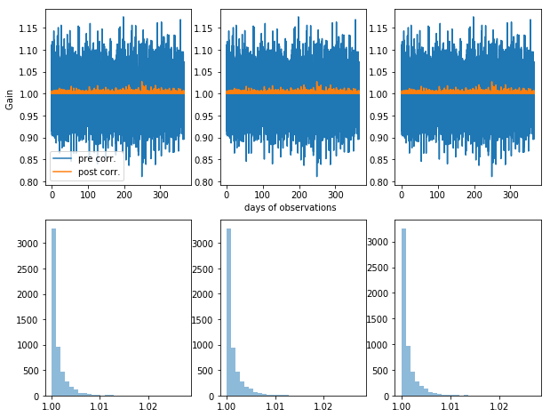

```python
import pickle

def read_gain_file( filename ):
    with open(filename,'rb') as  f:
        g=pickle.load(f)
    gvals=[]
    for gdic in (g[::2]):
        tmp=[vals for vals in gdic.keys() ]
        gvals.append([gdic[t][1] for t in tmp ])
    return pl.concatenate(gvals )






#whitenoise
gtrue= read_gain_file('/Users/peppe/work/satellite_sims/whitenoise/true_gains0.pkl')
gpost=read_gain_file('/Users/peppe/work/satellite_sims/whitenoise/gain_post_0.pkl')
nobs=len(gtrue)

fig=pl.figure(figsize=(10,8))
pl.tight_layout()
#indx=pl.randint(0,(nobs), 2700 )
#gpost[indx]= 2 - (gpost[indx]  )
pl.subplot(2,3,1)
pl.plot(pl.arange(nobs)/15.,gtrue, '-', label='pre corr.')
pl.plot(pl.arange(nobs)/15.,gpost,'-', label='post corr.')
pl.ylabel(r'Gain ')

pl.legend(loc='best')
pl.subplot(2,3,4)
foo = pl.hist(gpost, bins=30, alpha=.5)

#1/f
gtrue= read_gain_file('/Users/peppe/work/satellite_sims/fknee_20mHz/true_gains0.pkl')
gpost= read_gain_file('/Users/peppe/work/satellite_sims/fknee_20mHz/gain_post_0.pkl')
indx=pl.randint(0,(nobs), 2700 )

#gpost[indx]= 2 - (gpost[indx]  )

pl.subplot(2,3,2)
pl.plot(pl.arange(nobs)/15.,gtrue, '-')
pl.plot(pl.arange(nobs)/15.,gpost,'-')
pl.xlabel('days of observations  ')

pl.subplot(2,3,5)
foo = pl.hist(gpost, bins=30, alpha=.5)
gtrue= read_gain_file('/Users/peppe/work/satellite_sims/fknee_50mHz/true_gains0.pkl')
gpost= read_gain_file('/Users/peppe/work/satellite_sims/fknee_50mHz/gain_post_0.pkl')
#indx=pl.randint(0,(nobs), 2700 )

#gpost[indx]= 2 - (gpost[indx]  )

pl.subplot(2,3,3)
pl.plot(pl.arange(nobs)/15.,gtrue, '-')
pl.plot(pl.arange(nobs)/15.,gpost,'-')
pl.subplot(2,3,6)
foo = pl.hist(gpost, bins=30, alpha=.5)
```

the histogram show that the *post-correction* gain distribution is almost centered on 1 with few outliers around below 1% level, (as you can notice in the top row panels the gain fluctations are way larger than this threshold. Moreover, the estimator strongly relies on the template chosen, the stronger is the template (wrt the noise level) , the less uncertain will be the gain estimation. in this regard, the dipole ( 3 mK ) is a good template.

## To do's

- The time scale so far adopted is too long. In reality gain fluctates in a smaller time scale. Try to run the full gain systematics pipeline with a 1-2 minutes time scale
- Looks we have enough S/N ratio so that we don't necessary need the dipole as a template for the regression. Couple of test runs are on going with CMB T map.